# Minería de datos: PEC2 - Métodos no supervisados

```r
res_weight_culmen <- extractDBSCAN(res_weight_culmen, eps_cl = 0.06)
res_weight_culmen
```

```
## OPTICS ordering/clustering for 891 objects.
## Parameters: minPts = 10, eps = 0.287406004752579, eps_cl = 0.06, xi = NA
## The clustering contains 3 cluster(s) and 25 noise points.
##
##   0   1   2   3
##  25 550  65 251
##
## Available fields: order, reachdist, coredist, predecessor, minPts, eps,
##                   eps_cl, xi, cluster
```

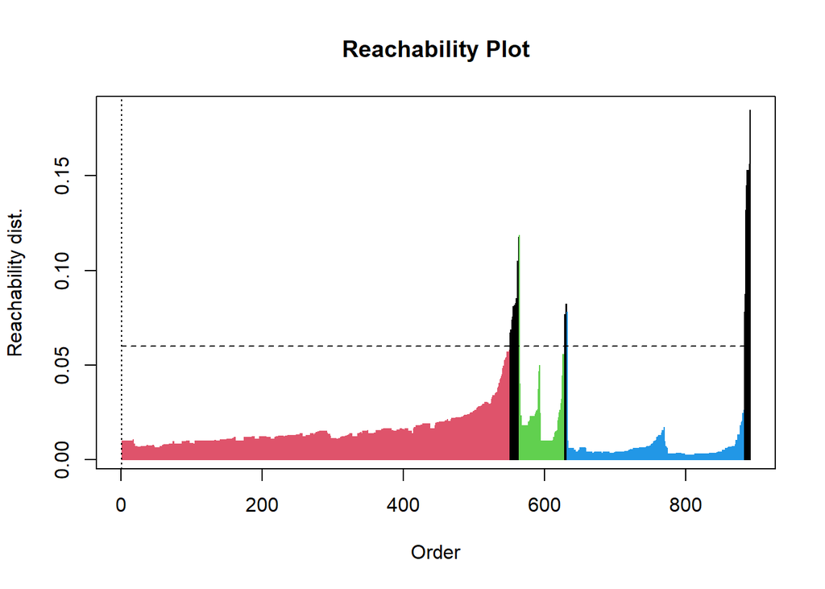

```r
plot(res_weight_culmen)
```

```r
res_weight_hallax <- extractDBSCAN(res_weight_hallax, eps_cl = 0.06)
res_weight_hallax
```

```
## OPTICS ordering/clustering for 891 objects.
## Parameters: minPts = 10, eps = 0.907724416965764, eps_cl = 0.06, xi = NA
## The clustering contains 1 cluster(s) and 9 noise points.
##
##   0   1
##   9 882
##
## Available fields: order, reachdist, coredist, predecessor, minPts, eps,
##                   eps_cl, xi, cluster
```

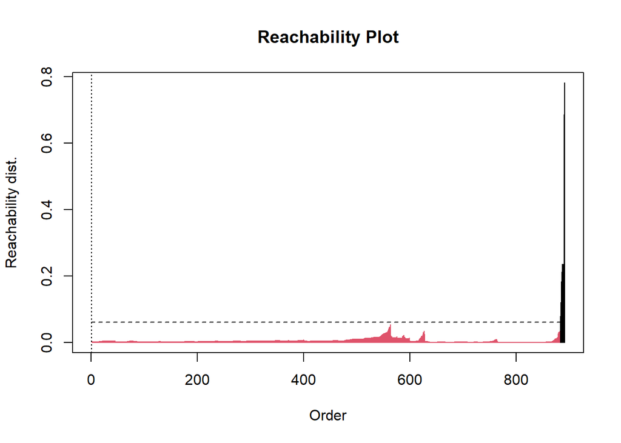

```r
plot(res_weight_hallax)
```

```r
res_culmen_hallax <- extractDBSCAN(res_culmen_hallax, eps_cl = 0.06)
res_culmen_hallax
```

```
## OPTICS ordering/clustering for 891 objects.
## Parameters: minPts = 10, eps = 0.920257988568104, eps_cl = 0.06, xi = NA
## The clustering contains 1 cluster(s) and 12 noise points.
##
##   0   1
##  12 879
##
## Available fields: order, reachdist, coredist, predecessor, minPts, eps,
##                   eps_cl, xi, cluster
```

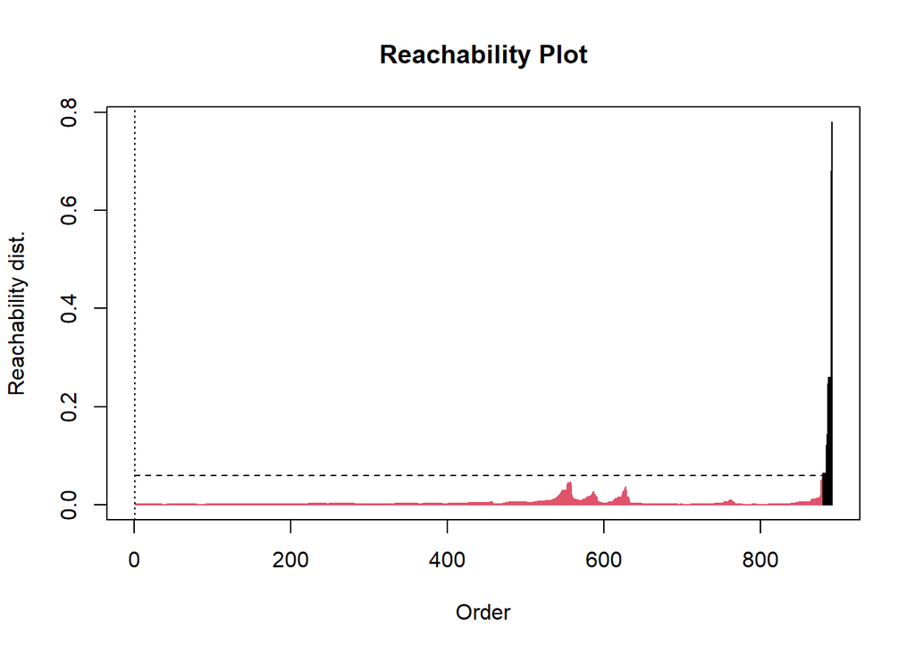

```r
plot(res_culmen_hallax)
```

Seguimos adelante con una representación gráfica que nos muestra los clusters mediante formas convexas.

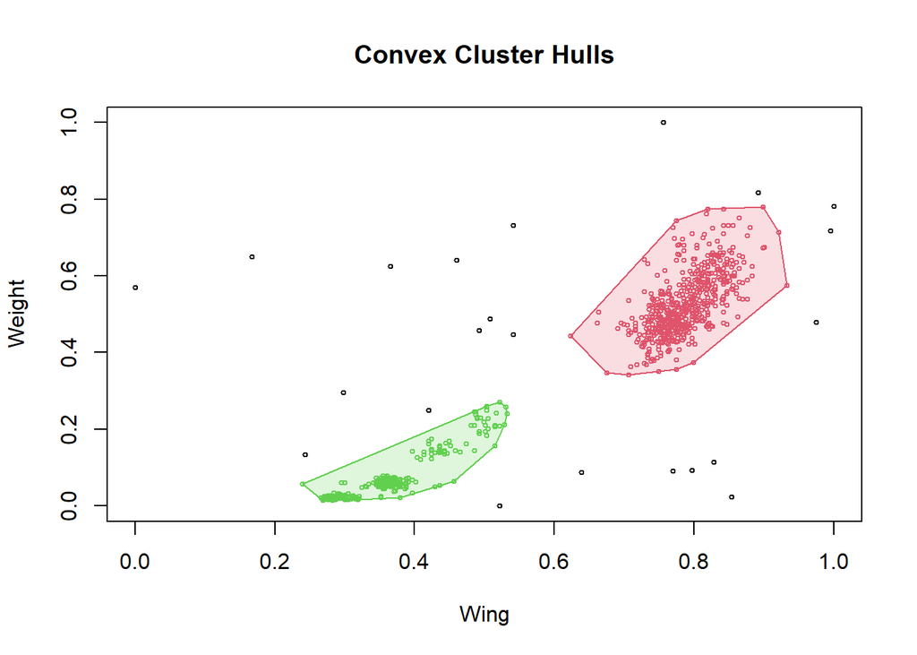

```r
hullplot(wing_weight, res_wing_weight)
```

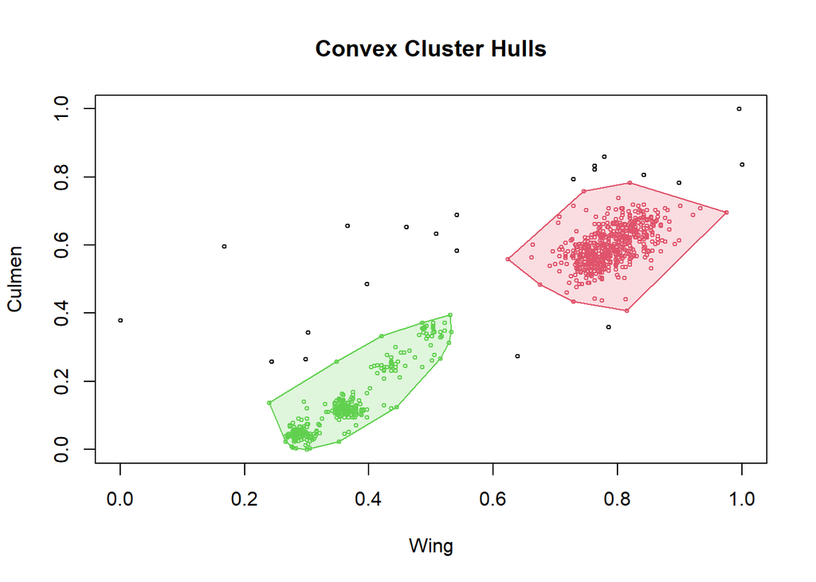

```r
hullplot(wing_culmen, res_wing_culmen)
```

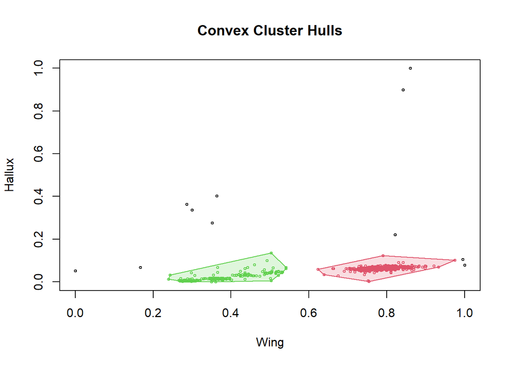

```r
hullplot(wing_hallax, res_wing_hallax)
```

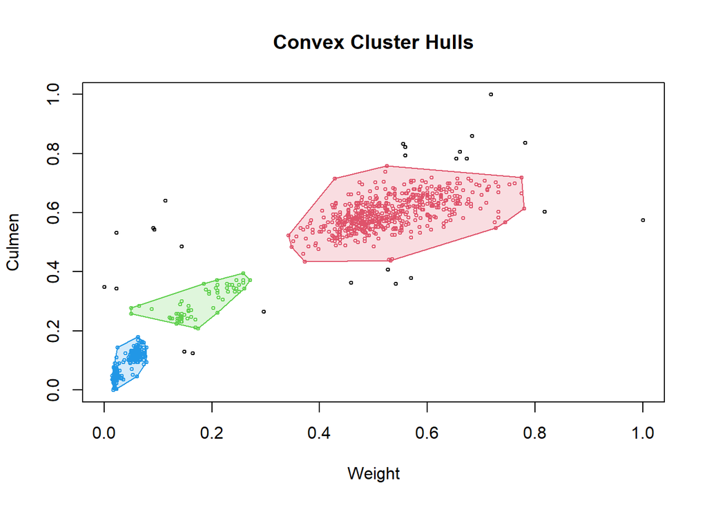

```r
hullplot(weight_culmen, res_weight_culmen)
```

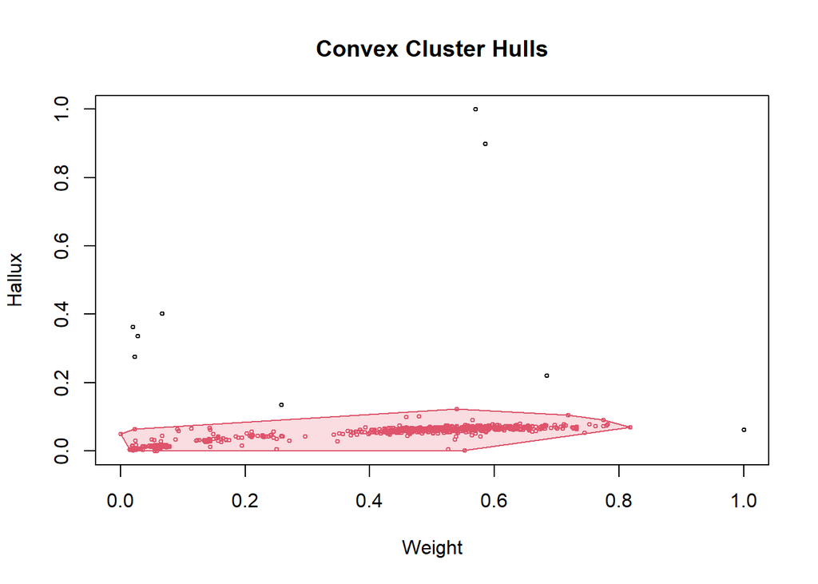

```r
hullplot(weight_hallax, res_weight_hallax)
```

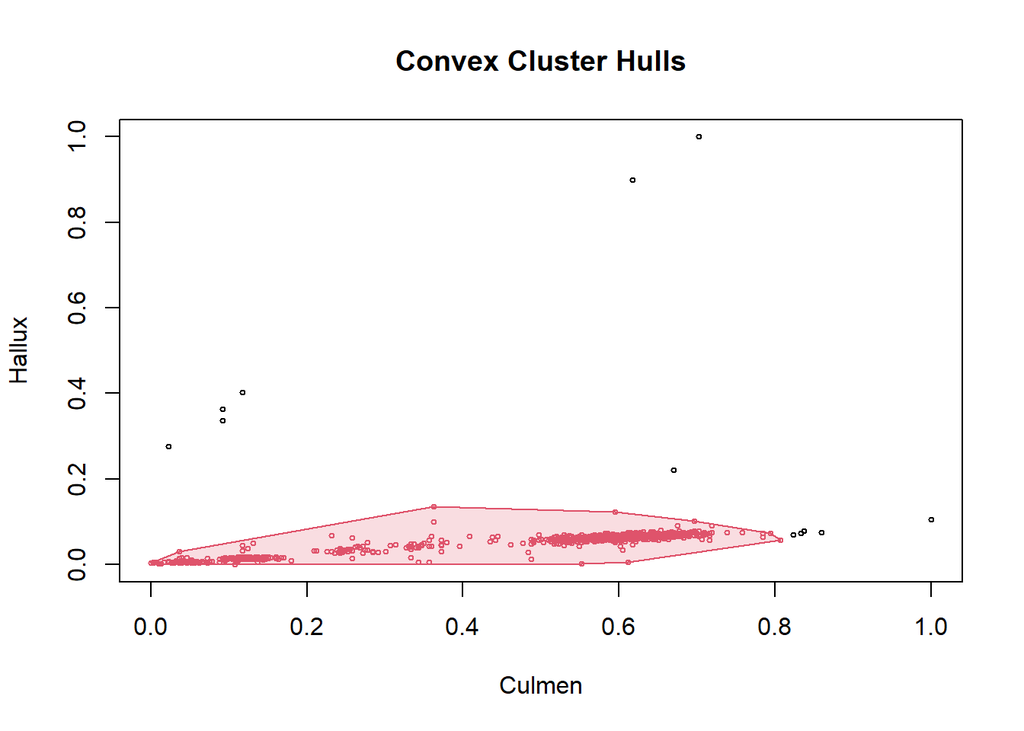

```r
hullplot(culmen_hallax, res_culmen_hallax)
```

Repetimos el experimento anterior incrementando el parámetro *epc_cl*, veamos como el efecto que produce es la concentración de clusters ya que flexibilizamos la condición de densidad.

```r
res_wing_weight <- extractDBSCAN(res_wing_weight, eps_cl = 0.1)
res_wing_weight
```

```
## OPTICS ordering/clustering for 891 objects.
## Parameters: minPts = 10, eps = 0.564691693714801, eps_cl = 0.1, xi = NA
## The clustering contains 2 cluster(s) and 16 noise points.
##
##   0   1   2
##  16 555 320
##
## Available fields: order, reachdist, coredist, predecessor, minPts, eps,
##                   eps_cl, xi, cluster
```

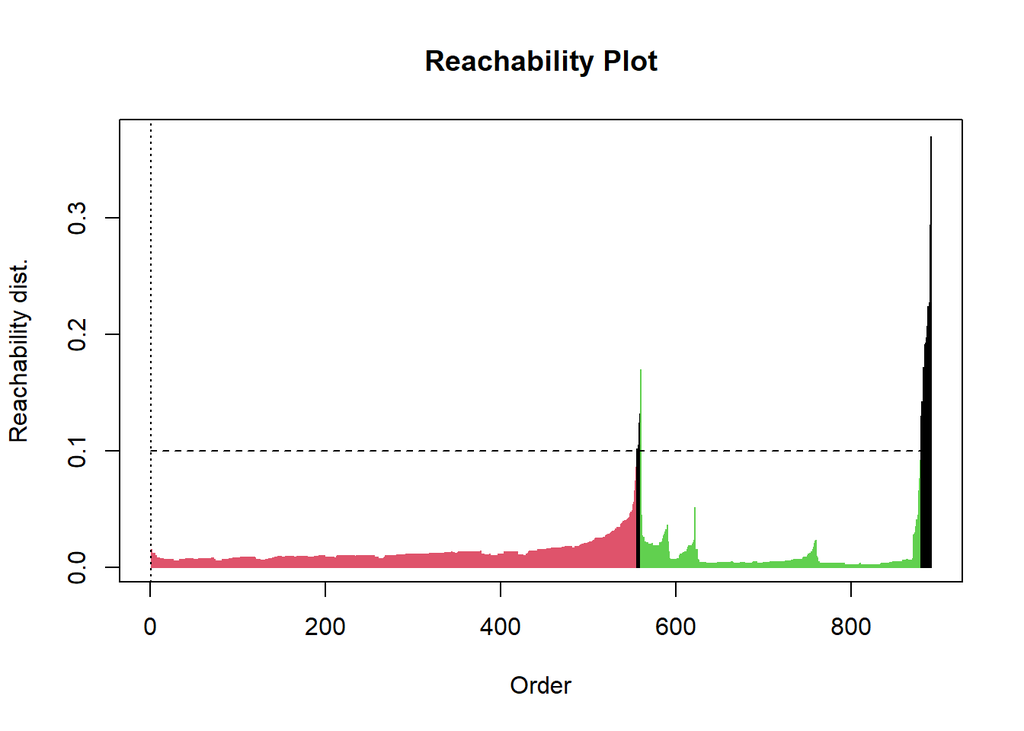

```r
plot(res_wing_weight)
```

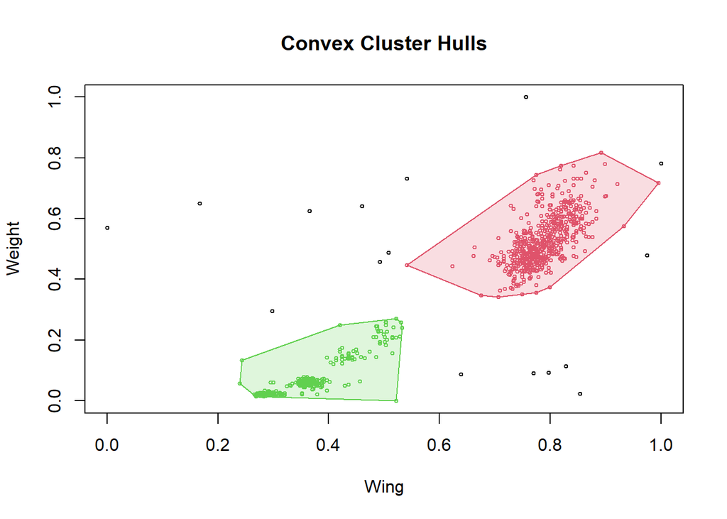

```r
hullplot(wing_weight, res_wing_weight)
```

```r
res_wing_culmen <- extractDBSCAN(res_wing_culmen, eps_cl = 0.1)
res_wing_culmen
```

```
## OPTICS ordering/clustering for 891 objects.
## Parameters: minPts = 10, eps = 0.409026103626258, eps_cl = 0.1, xi = NA
## The clustering contains 2 cluster(s) and 11 noise points.
##
##   0   1   2
##  11 560 320
##
## Available fields: order, reachdist, coredist, predecessor, minPts, eps,
##                   eps_cl, xi, cluster
```

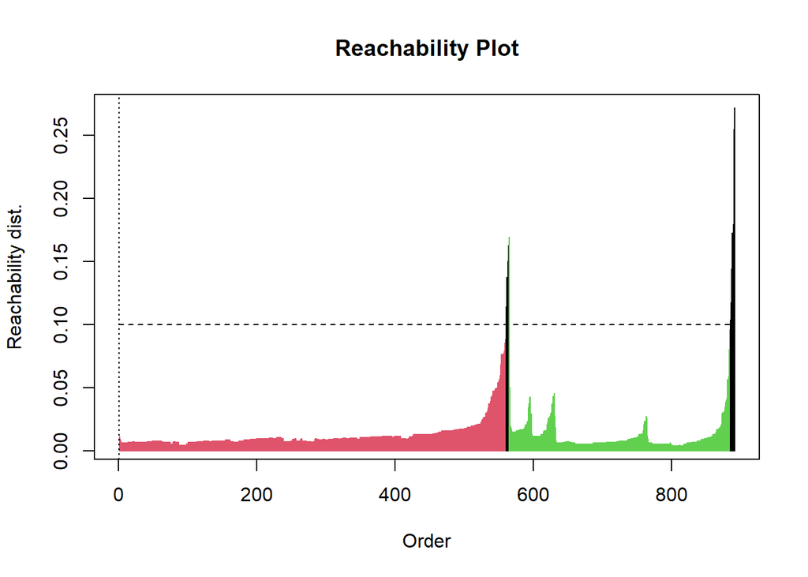

```r
plot(res_wing_culmen)
```

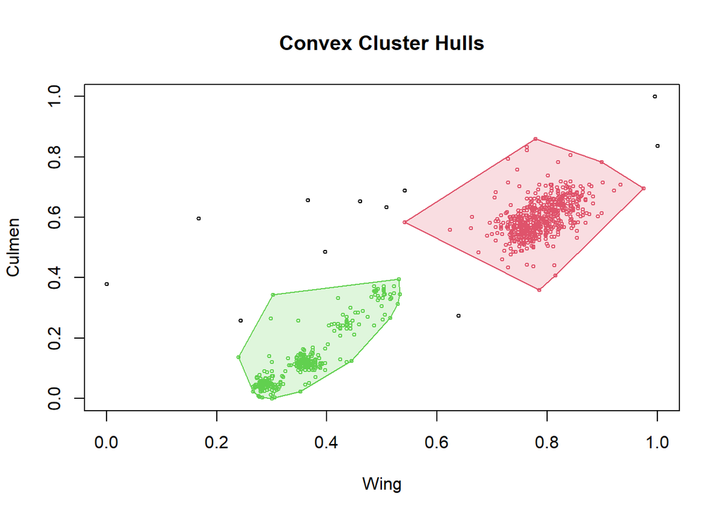

```r
hullplot(wing_culmen, res_wing_culmen)
```

```r
res_wing_hallax <- extractDBSCAN(res_wing_hallax, eps_cl = 0.1)
res_wing_hallax
```

```
## OPTICS ordering/clustering for 891 objects.
## Parameters: minPts = 10, eps = 0.908887026048843, eps_cl = 0.1, xi = NA
## The clustering contains 1 cluster(s) and 8 noise points.
##
##   0   1
##   8 883
##
## Available fields: order, reachdist, coredist, predecessor, minPts, eps,
##                   eps_cl, xi, cluster
```

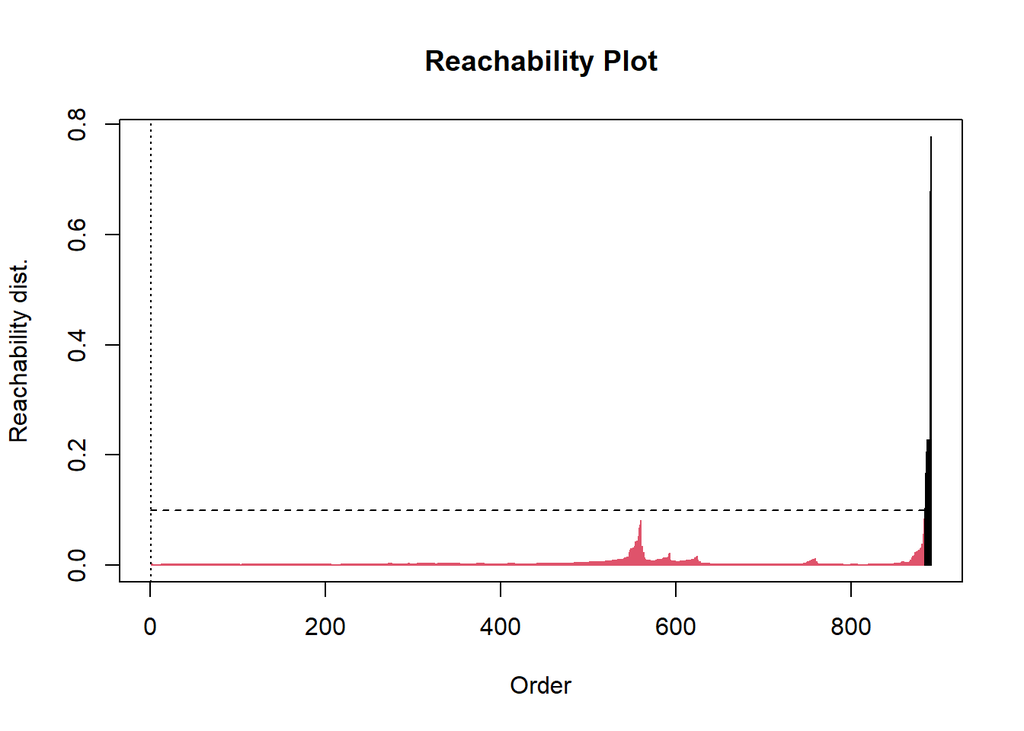

```r
plot(res_wing_hallax)
```

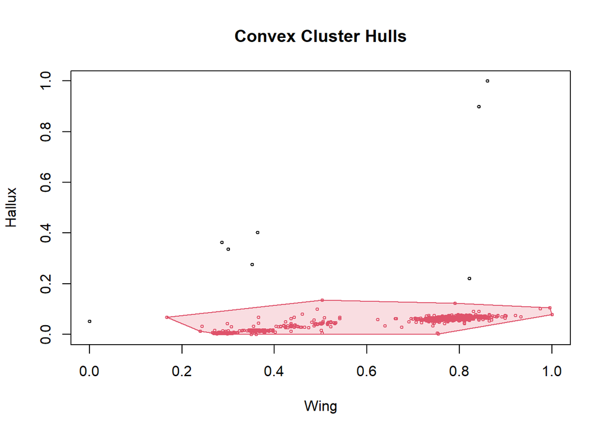

```r
hullplot(wing_hallax, res_wing_hallax)
```

```r
res_weight_culmen <- extractDBSCAN(res_weight_culmen, eps_cl = 0.1)
res_weight_culmen
```

```
## OPTICS ordering/clustering for 891 objects.
## Parameters: minPts = 10, eps = 0.287406004752579, eps_cl = 0.1, xi = NA
## The clustering contains 2 cluster(s) and 9 noise points.
##
##   0   1   2
##   9 561 321
##
## Available fields: order, reachdist, coredist, predecessor, minPts, eps,
##                   eps_cl, xi, cluster
```

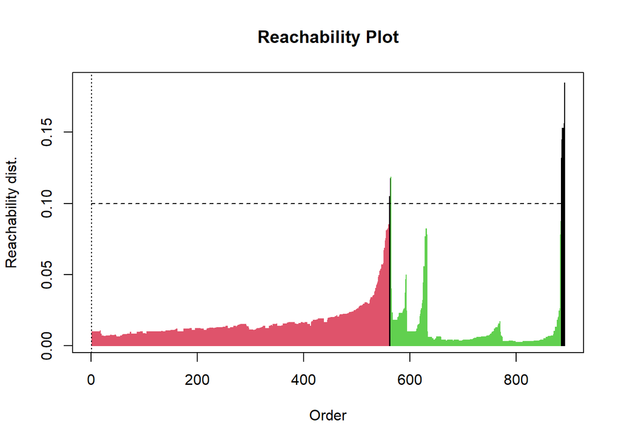

```r
plot(res_weight_culmen)
```

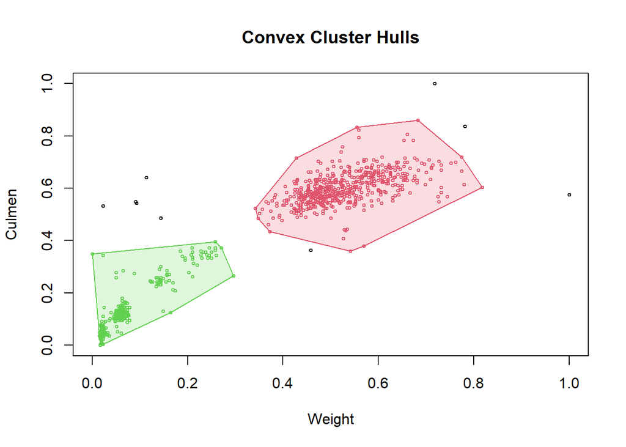

```r
hullplot(weight_culmen, res_weight_culmen)
```

```r
res_weight_hallax <- extractDBSCAN(res_weight_hallax, eps_cl = 0.1)
res_weight_hallax
```

```
## OPTICS ordering/clustering for 891 objects.
## Parameters: minPts = 10, eps = 0.907724416965764, eps_cl = 0.1, xi = NA
## The clustering contains 1 cluster(s) and 8 noise points.
##
##   0   1
##   8 883
##
## Available fields: order, reachdist, coredist, predecessor, minPts, eps,
##                   eps_cl, xi, cluster
```

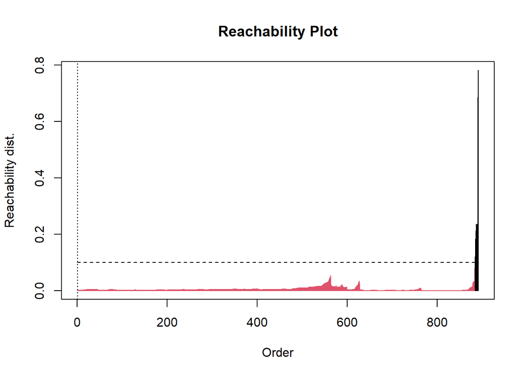

```r
plot(res_weight_hallax)
```

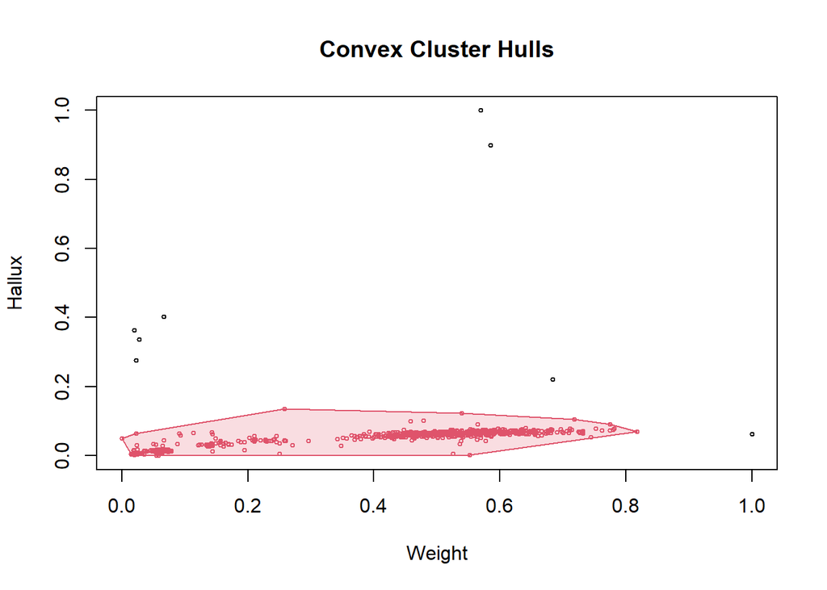

```r
hullplot(weight_hallax, res_weight_hallax)
```

```r
res_culmen_hallax <- extractDBSCAN(res_culmen_hallax, eps_cl = 0.1)
res_culmen_hallax
```

```
## OPTICS ordering/clustering for 891 objects.
## Parameters: minPts = 10, eps = 0.920257988568104, eps_cl = 0.1, xi = NA
## The clustering contains 1 cluster(s) and 8 noise points.
##
##   0   1
##   8 883
##
## Available fields: order, reachdist, coredist, predecessor, minPts, eps,
##                   eps_cl, xi, cluster
```

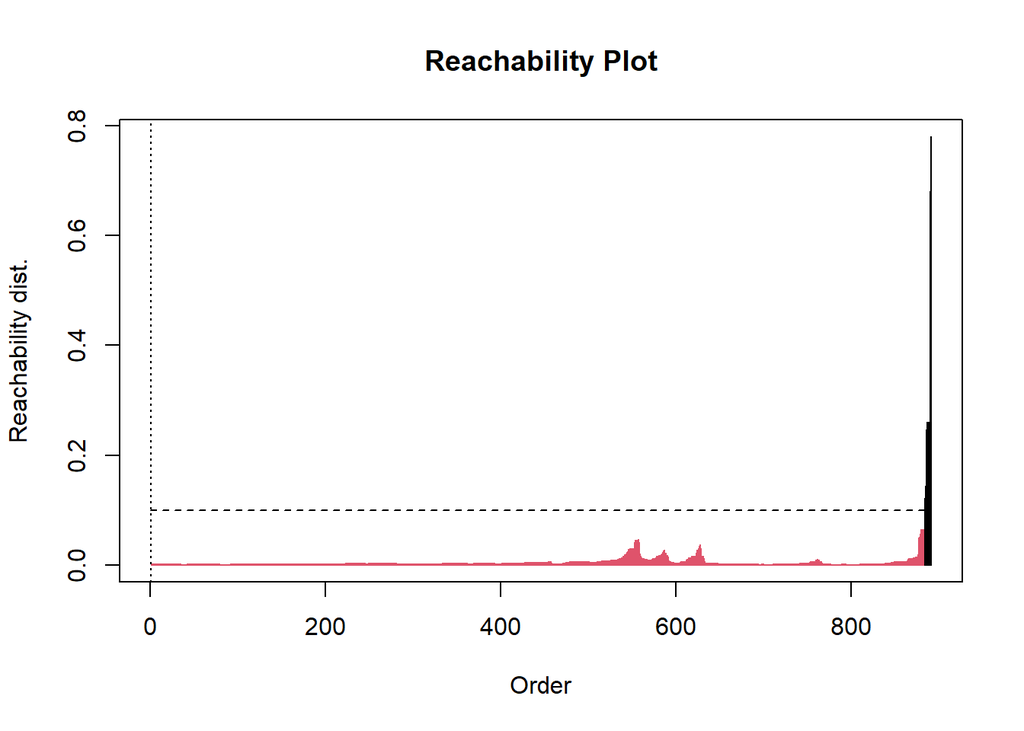

```r
plot(res_culmen_hallax)
```

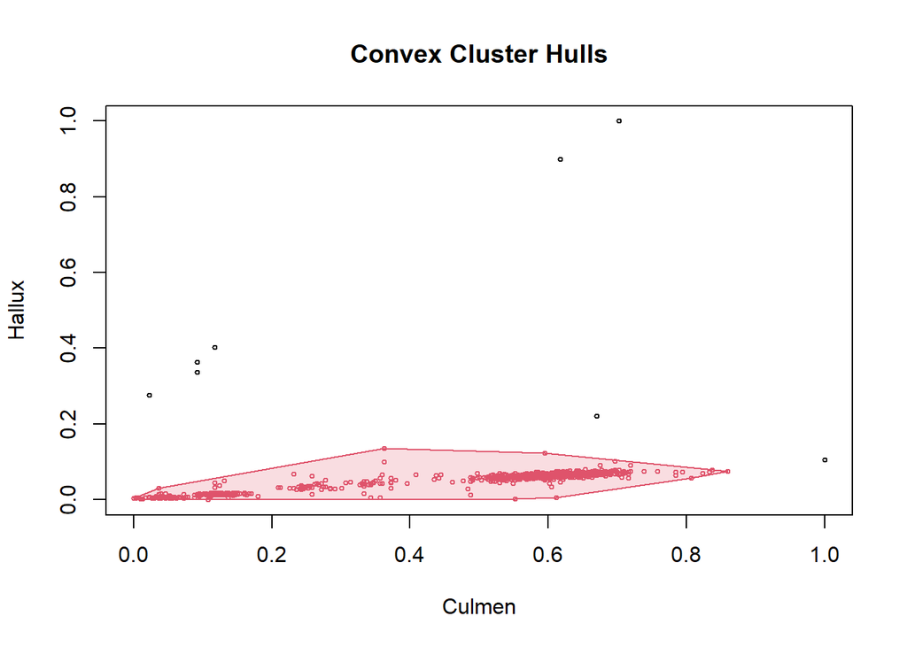

```r
hullplot(culmen_hallax, res_culmen_hallax)
```

Veamos ahora una variante de la extracción **DBSCN** anterior. En ella el parámetro *xi* nos va a servir para clasificar los clusters en función del cambio en la densidad relativa de los mismos.

```r
### Extracción del clustering jerárquico en función de la variación de la densidad por el método xi
res_wing_weight <- extractXi(res_wing_weight, xi = 0.1)
res_wing_weight
```

```
## OPTICS ordering/clustering for 891 objects.
## Parameters: minPts = 10, eps = 0.564691693714801, eps_cl = NA, xi = 0.1
## The clustering contains 11 cluster(s) and 1 noise points.
##
## Available fields: order, reachdist, coredist, predecessor, minPts, eps,
##                   eps_cl, xi, cluster, clusters_xi
```

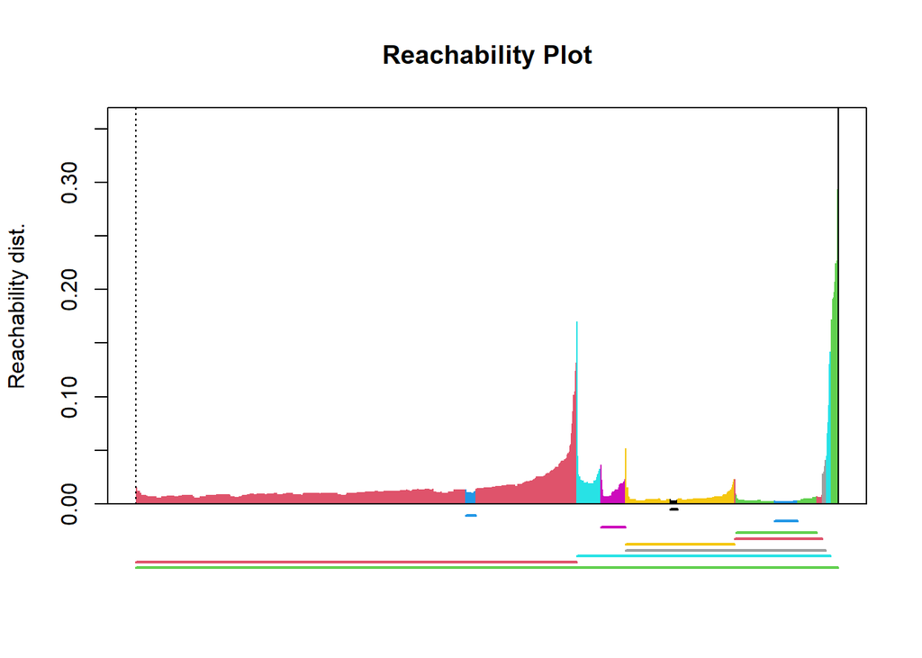

```r
plot(res_wing_weight)
```

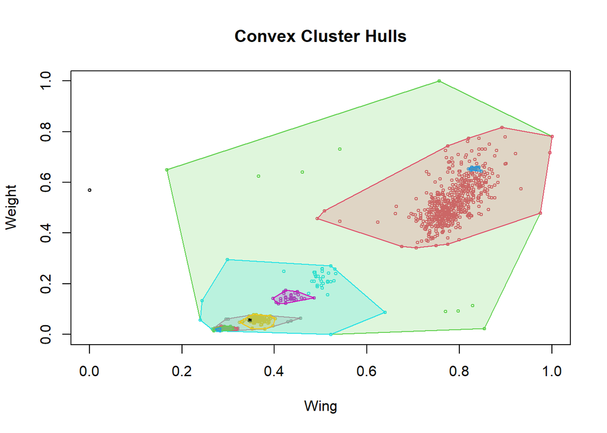

```r
hullplot(wing_weight, res_wing_weight)
```

```r
res_wing_culmen <- extractXi(res_wing_culmen, xi = 0.1)
res_wing_culmen
```

```
## OPTICS ordering/clustering for 891 objects.
## Parameters: minPts = 10, eps = 0.409026103626258, eps_cl = NA, xi = 0.1
## The clustering contains 11 cluster(s) and 0 noise points.
##
## Available fields: order, reachdist, coredist, predecessor, minPts, eps,
##                   eps_cl, xi, cluster, clusters_xi
```

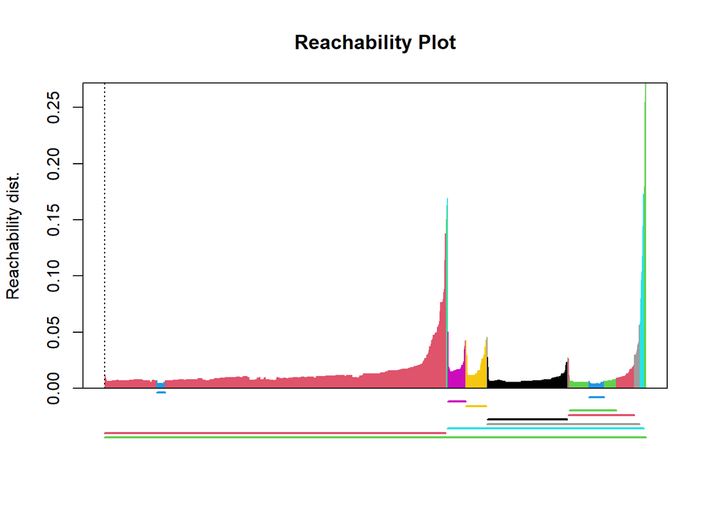

```r
plot(res_wing_culmen)
```

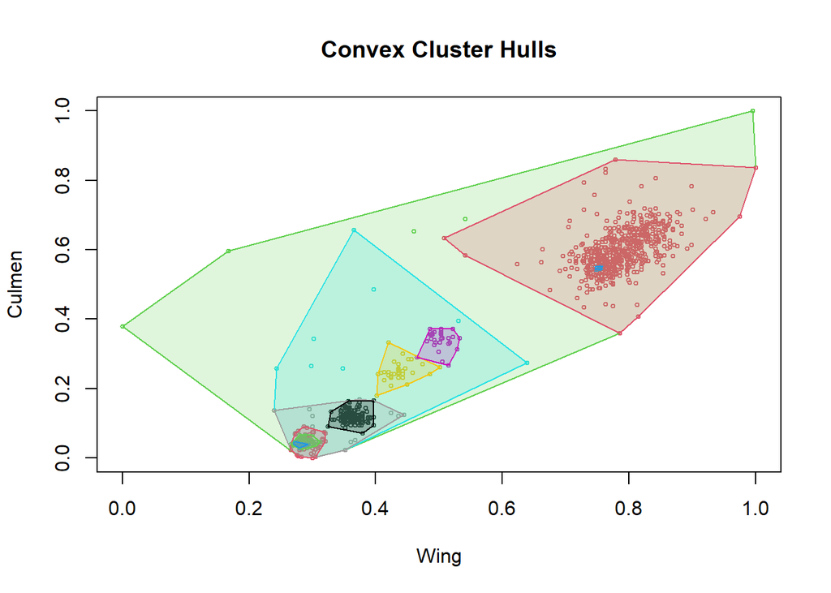

```r
hullplot(wing_culmen, res_wing_culmen)
```

```r
res_wing_hallax <- extractXi(res_wing_hallax, xi = 0.1)
res_wing_hallax
```

```
## OPTICS ordering/clustering for 891 objects.
## Parameters: minPts = 10, eps = 0.908887026048843, eps_cl = NA, xi = 0.1
## The clustering contains 14 cluster(s) and 1 noise points.
##
## Available fields: order, reachdist, coredist, predecessor, minPts, eps,
##                   eps_cl, xi, cluster, clusters_xi
```

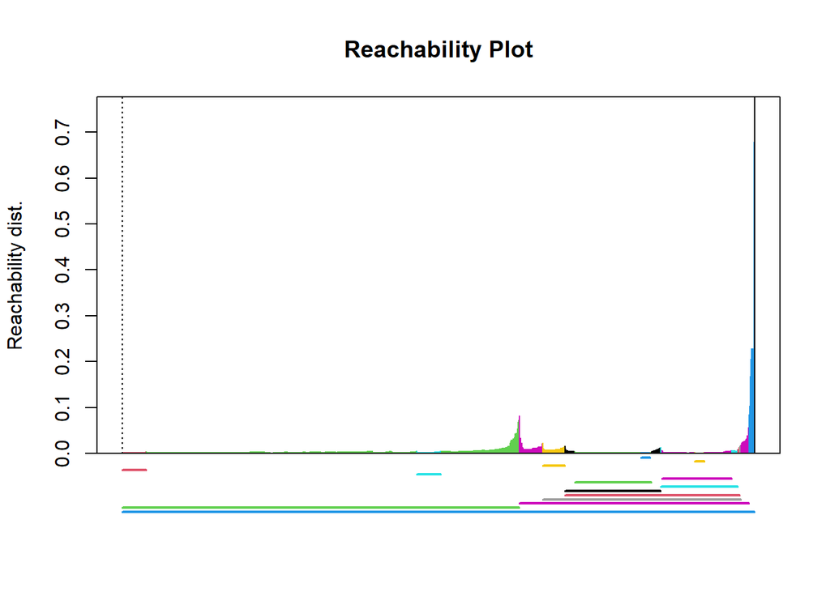

```r
plot(res_wing_hallax)
```

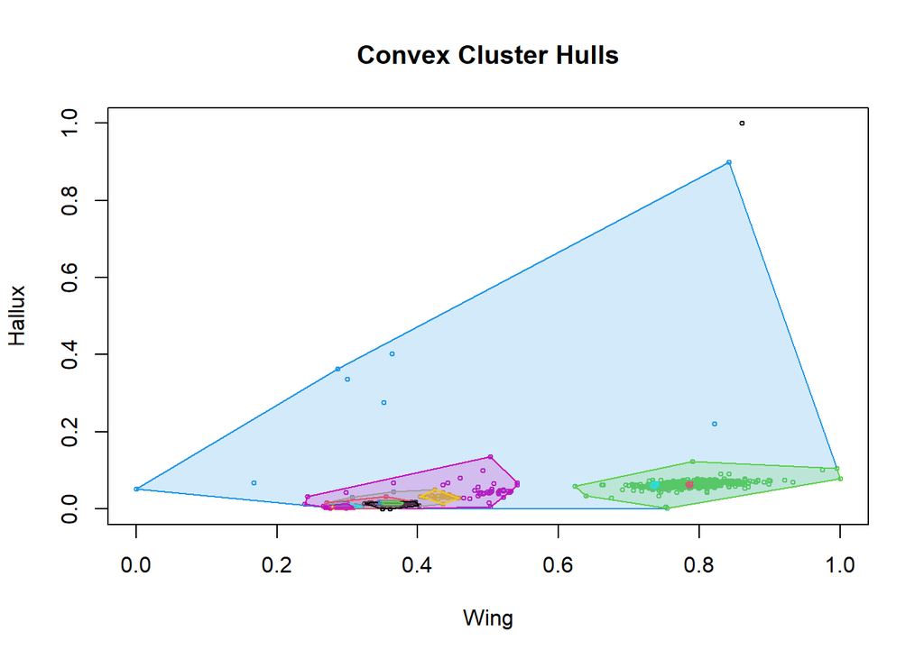

```r
hullplot(wing_hallax, res_wing_hallax)
```

```r
res_weight_culmen <- extractXi(res_weight_culmen, xi = 0.1)
res_weight_culmen
```

```
## OPTICS ordering/clustering for 891 objects.
## Parameters: minPts = 10, eps = 0.287406004752579, eps_cl = NA, xi = 0.1
## The clustering contains 10 cluster(s) and 1 noise points.
##
## Available fields: order, reachdist, coredist, predecessor, minPts, eps,
##                   eps_cl, xi, cluster, clusters_xi
```

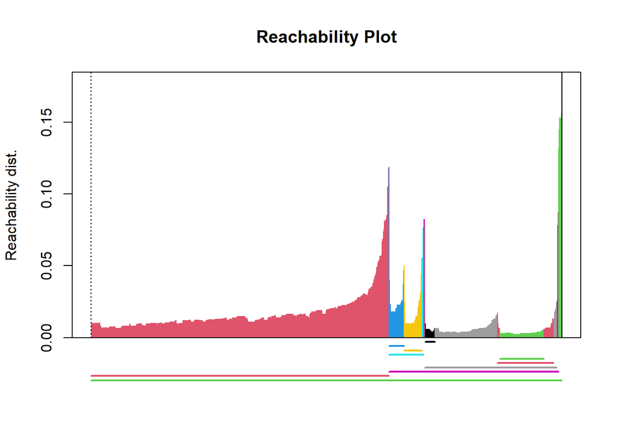

```r
plot(res_weight_culmen)
```

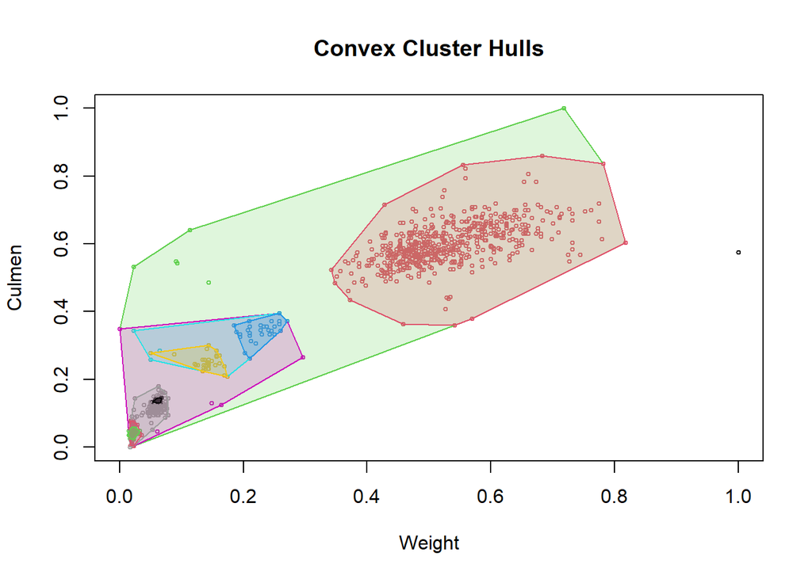

```r
hullplot(weight_culmen, res_weight_culmen)
```

```r
res_weight_hallax <- extractXi(res_weight_hallax, xi = 0.1)
res_weight_hallax
```

```
## OPTICS ordering/clustering for 891 objects.
## Parameters: minPts = 10, eps = 0.907724416965764, eps_cl = NA, xi = 0.1
## The clustering contains 16 cluster(s) and 1 noise points.
##
## Available fields: order, reachdist, coredist, predecessor, minPts, eps,
##                   eps_cl, xi, cluster, clusters_xi
```

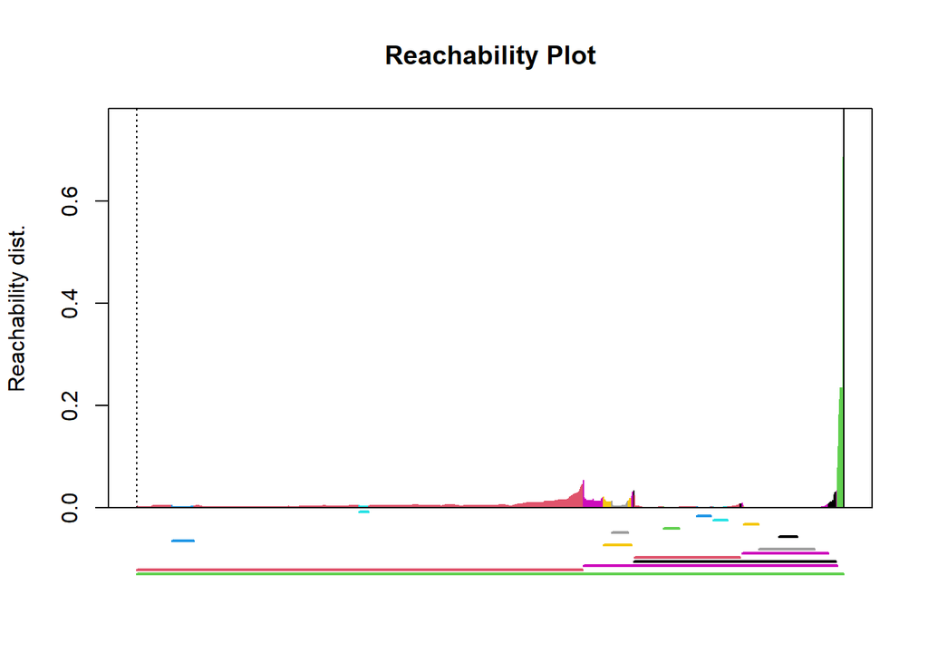

```r
plot(res_weight_hallax)
```

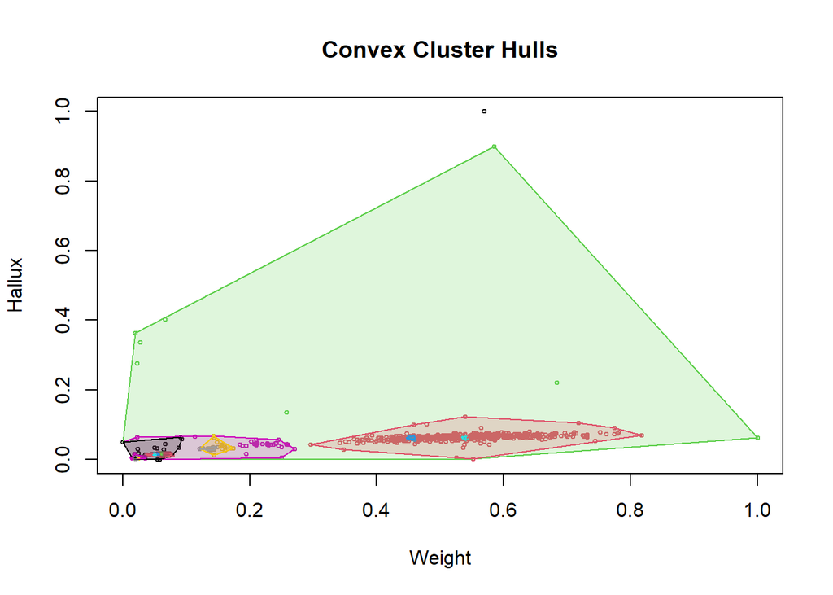

```r
hullplot(weight_hallax, res_weight_hallax)
```

```r
res_culmen_hallax <- extractXi(res_culmen_hallax, xi = 0.1)
res_culmen_hallax
```

```
## OPTICS ordering/clustering for 891 objects.
## Parameters: minPts = 10, eps = 0.920257988568104, eps_cl = NA, xi = 0.1
## The clustering contains 19 cluster(s) and 1 noise points.
##
## Available fields: order, reachdist, coredist, predecessor, minPts, eps,
##                   eps_cl, xi, cluster, clusters_xi
```

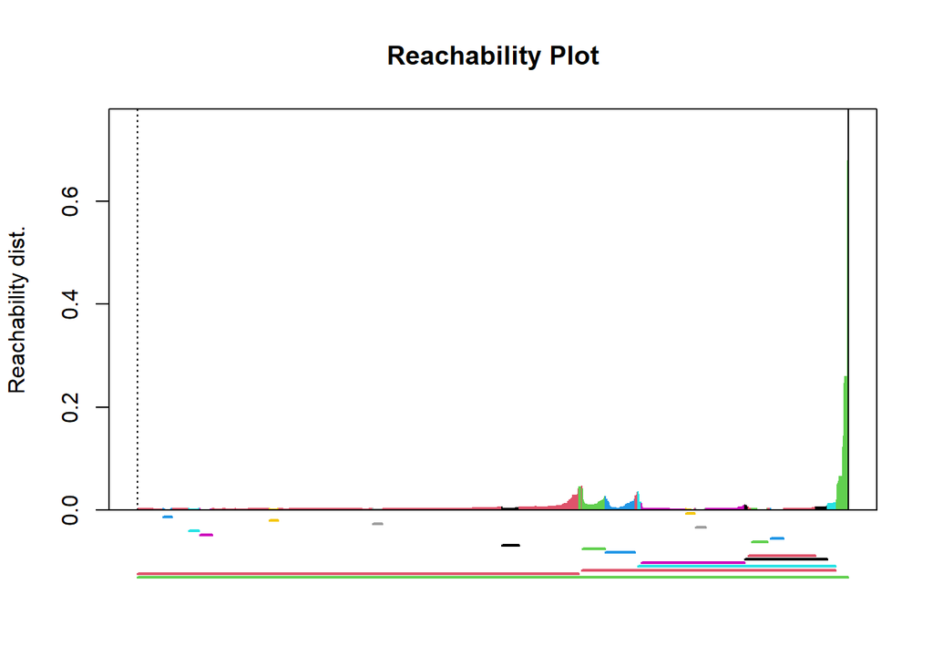

```r
plot(res_culmen_hallax)
```

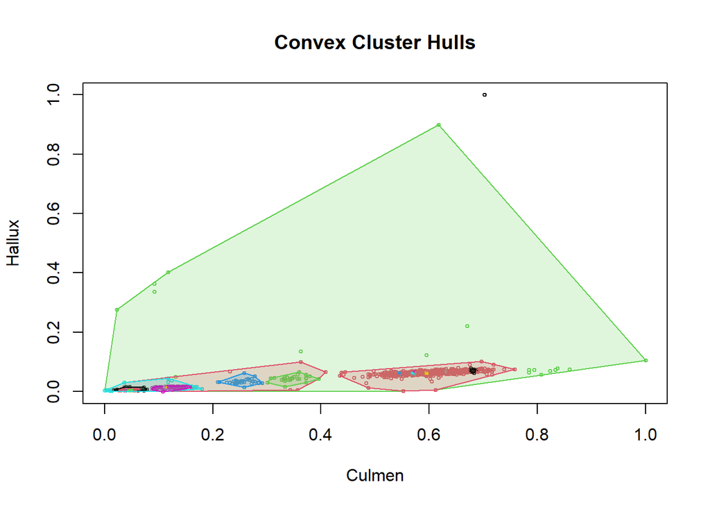

```r
hullplot(culmen_hallax, res_culmen_hallax)
```

## Ejercicio 3

Realiza una comparativa de los métodos *k-means* y *DBSCAN*

### Respuesta 3

#### K-Means vs DBSCAN

El algoritmo DBSCAN agrupa los clústers en función de la densidad de la siguiente manera:

1. Se asigna un mínimo número de puntos de vecindad y un radio máximo.
2. Se escoge un punto aleatorio y se traza un círculo de radio igual al radio máximo asignado
3. Si en el círculo trazado se encuentra un número de puntos igual o superior al mínimo número de puntos de vecindad, se incluye en el clúster y se origina un nuevo círculo a partir de estos. En caso contrario, se excluye.

El algoritmo K-Means aprupa los clústers de la siguiente manera:

1. Se asigna un número k de clúster establecidos de antemano a partir de puntos escogidos aleatoriamente.
2. Se asignan puntos a un clúster en función de la mínima distancia del punto al clúster.
3. Se reasigna que punto se considera el centro del clúster a partir de la media de todas las distancias obtenidas en el clúster.
4. Se repite hasta que no se pueda mejorar más.

Ambos algoritmos requieren que se les introduzca valores de antemano para calibrar la agrupación que generan y ambos son de tipo no supervisado.

DBSCAN es mejor que K-Means en tanto y en cuanto éste es capaz de adaptarse a figuras más irregulares, diferentes densidades y el número de clústers no está predefinido, sin embargo, K-Means resulta más eficiente si hablamos de tiempo computacional y DBSCAN también requiere de parámetros iniciales para realizar el cálculo.

#### Comparando valores

Hemos observado como ambos algoritmos son capaces de agrupar características en función de lo agrupados que se encuentran los puntos, aunque todo depende de que parámetros iniciales se escogan.

#### Conclusión final

Ambos algoritmos no han sido capaces de generar agrupaciones que corresponan al tipo de espécie, por lo que podemos concluir que que las características *Wing*, *Weight*, *Culmen* y *Hallax* no pueden determinar la espécie a la que pertenece un halcón, pues la relación de estas variables entre ellas es muy débil y sus puntos se encuentras muy diluidos entre sí.